# Predicción Conformal — Sulam

Predicción Conformal

Cómo construir predictores con incertidumbre

Jeremias Sulam

2da Escuela Primavera de Deep Learning

ICC, CONICET–UBA · Noviembre 2026

[figure not shown]

[figure not shown]

## IA: un cambio de paradigma

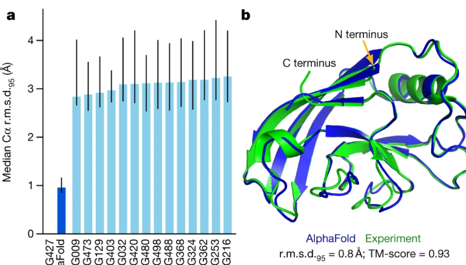

Estructura 3D de proteínas a partir de la secuencia, con precisión cercana a la experimental en CASP14.

Jumper et al., Nature 2021

[video not shown]

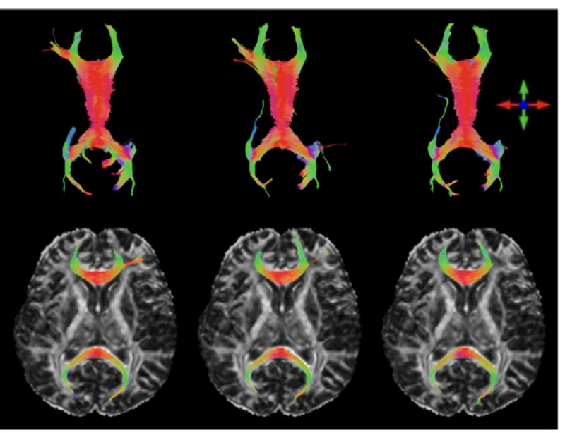

Tensores de susceptibilidad magnética del cerebro (MRI) reconstruidos con menos orientaciones de adquisición.

DeepSTI: Fang et al., MedIA 2023

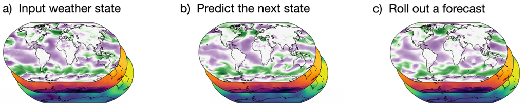

Pronóstico meteorológico a 10 días, mejor que el sistema operativo del ECMWF en el 90% de 1380 variables evaluadas.

Lam et al., Science 2023

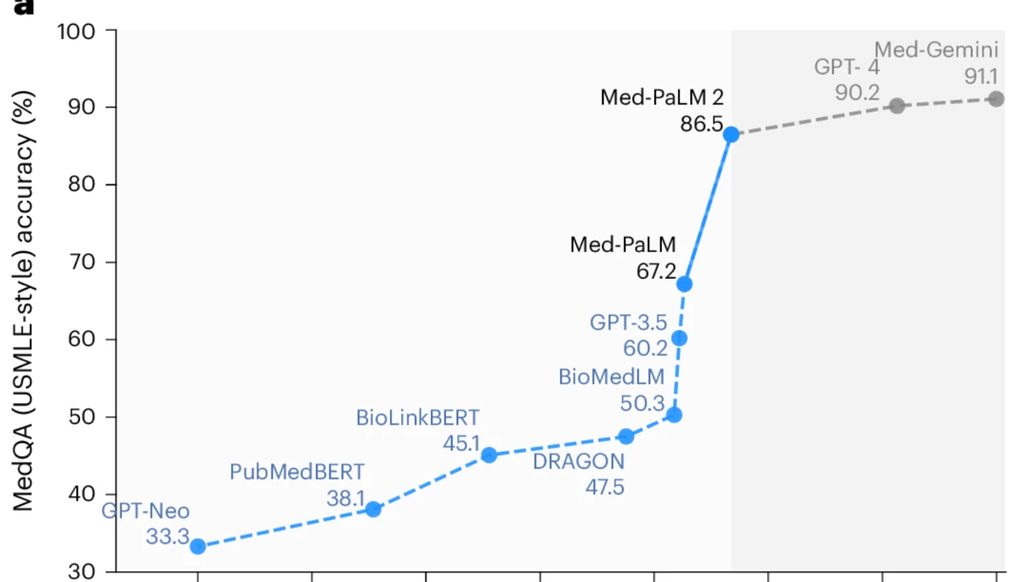

Modelos de lenguaje con 86.5% de aciertos en preguntas de examen médico (MedQA).

Singhal et al., Nature Medicine 2025

## … pero a veces falla

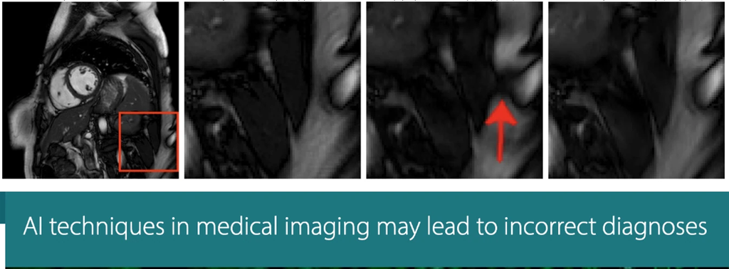

Perturbaciones pequeñas en las mediciones producen estructuras falsas (flecha) en reconstrucciones con redes profundas.

Univ. of Cambridge, 12 mayo 2020 · Antun et al., PNAS 2020

[figure not shown]

Modelo comercial de sepsis: AUC 0.63 en validación externa; no detectó el 67% de los casos.

MedCity News, 23 junio 2021 · Wong et al., JAMA Intern. Med. 2021

[figure not shown]

Clasificadores de COVID-19 en radiografías usan señales espurias y fallan en hospitales nuevos.

GeekWire, 3 junio 2021 · DeGrave, Janizek & Lee, Nat. Mach. Intell. 2021

[figure not shown]

Un escrito judicial citó seis fallos inexistentes generados por un LLM.

The New York Times, 27 mayo 2023 · Mata v. Avianca, S.D.N.Y. 2023

Los predictores en general solo nos dan un valor predicho.

¿Cómo podemos asociar estas predicciones con su incertidumbre de manera rigurosa?

## Predicción puntual

Datos de entrenamiento $(X_i, Y_i)\sim P$, $\ i=1,\dots,n$, y una pérdida $\ell$:
$$\fh = \argmin_{f\in\mathcal F}\ \frac1n\sum_{i=1}^n \ell\big(f(X_i),Y_i\big) \quad\approx\quad f^\star=\argmin_f\ \E\big[\ell(f(X),Y)\big]$$

Regresión: $\ Y\in\R$

$$f^\star(x)=\E[Y\mid X=x]$$
pérdida cuadrática $\ \ell=(f(x)-y)^2$

Clasificación: $\ Y\in[K]$

$$f^\star_k(x)=\P(Y=k\mid X=x)$$
entropía cruzada; $\ \hat y(x)=\argmax_k \fh_k(x)$

## Predicción puntual

$X$ = edad y sexo. $\ Y$ = peso (kg).

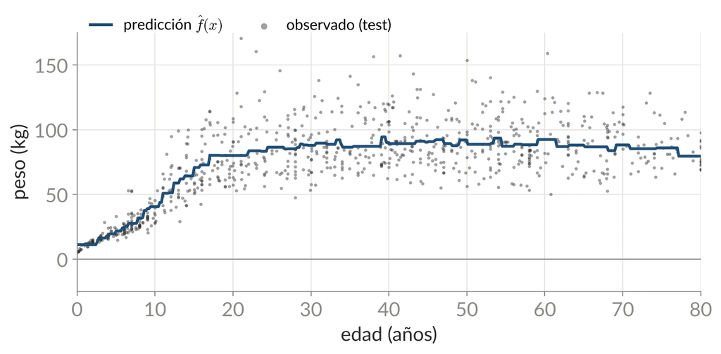

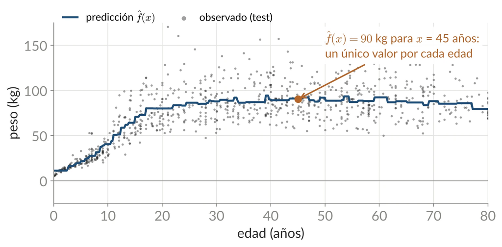

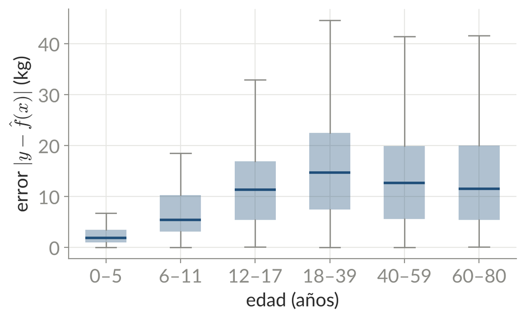

Error en test $|y-\fh(x)|$: en promedio 2.6 kg de 0 a 5 años y 17 kg de 18 a 39.

El error depende de $x$. ¿Cuál es la incertidumbre de cada predicción?

[NHANES 2009–2012, n = 6 724; Pruim, 2015]

Q1: ¿Cómo construir intervalos de incertidumbre precisos?

Q2: ¿Cómo se generaliza y dónde se aplica?

## Intervalos de predicción

Alrededor de cualquier predictor:
$$C_\lambda(x) = \big[\fh(x)-\lambda,\ \fh(x)+\lambda\big]$$

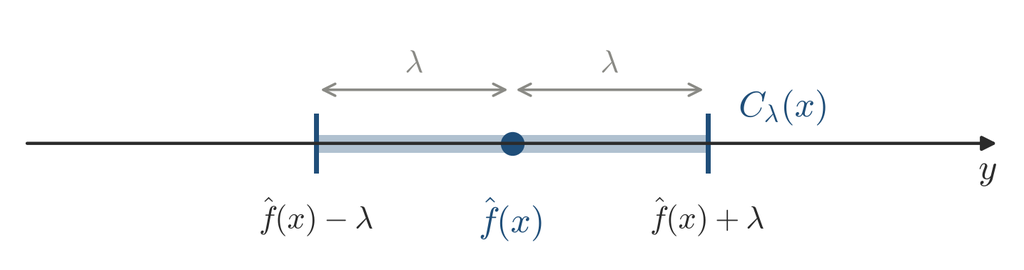

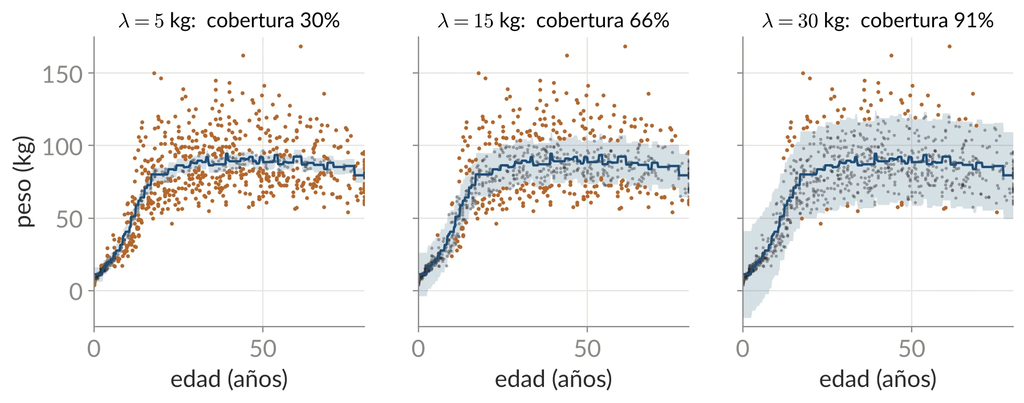

¿Cómo elegir $\lambda$ para que $\quad \P\big[Y\in C_\lambda(X)\big]\ \ge\ 1-\alpha\$?

## Intervalos de predicción

¿Cómo elegir $\lambda$ para que $\quad \P\big[Y\in C_\lambda(X)\big]\ \ge\ 1-\alpha\$?

- **Desviación estándar del error:** $\ \lambda = z_{1-\alpha/2}\,\hat\sigma$  
  supone errores gaussianos, con la misma varianza para todo $x$

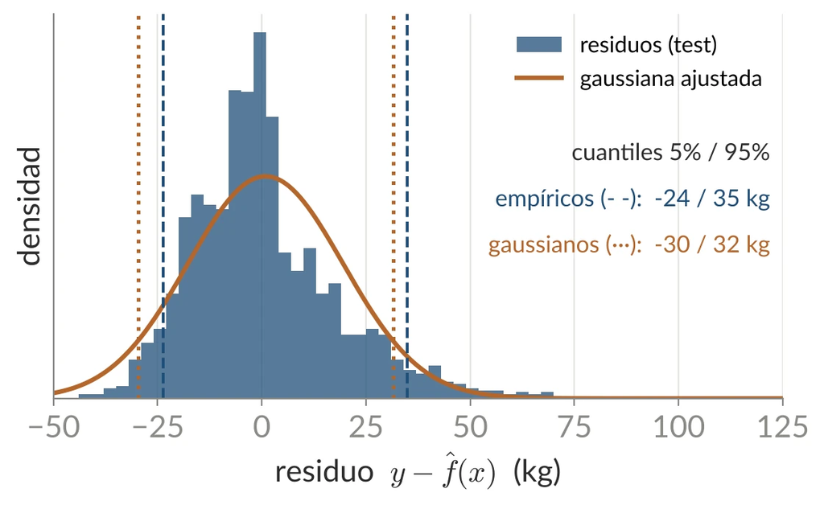

Peso según la edad: residuos en test asimétricos y de colas pesadas (asimetría 1.3, curtosis en exceso 3.5).

- **Bayesiano:** intervalo creíble de la distribución predictiva posterior  
  $\ p(y\mid x,\mathcal D)=\int p(y\mid x,\theta)\,p(\theta\mid\mathcal D)\,d\theta$  
  válido si el prior y la verosimilitud son correctos; la integral sobre $\theta$ es intratable para redes profundas
- **MC dropout / ensembles:** media $\pm$ desviación entre pasadas o redes  
  aproximaciones a la posterior sin control del error de aproximación

Ninguna garantiza cobertura $1-\alpha$ con muestra finita y sin supuestos.

[Gal & Ghahramani, 2016][Lakshminarayanan et al, 2017]

## Intervalos de predicción

¿Cómo elegir $\lambda$ para que $\quad \P\big[Y\in C_\lambda(X)\big]\ \ge\ 1-\alpha\$?

- para **cualquier** modelo $\fh$ (red, ensemble, LLM, una API)
- para **cualquier** distribución de los datos (sin supuestos paramétricos)
- con **muestra finita** (no asintótico)

Requisito: $n$ datos etiquetados de calibración “intercambiables”.

## Split conformal

Entrada: un predictor $\fh$ ya entrenado (con otros datos, o accesible solo a través de una API) y $n$ datos de calibración $(X_i,Y_i)$.

**1.** Calcular los **scores** $\ s_i = |Y_i-\fh(X_i)|$, $\ i=1,\dots,n$.

**2.** $\qh$ = cuantil empírico de nivel $\ \dfrac{\lceil (n+1)(1-\alpha)\rceil}{n}\$ de $\ s_1,\dots,s_n$.

**3.** Para un nuevo $x$: $\qquad \Ch(x)=C_{\qh}(x)=\big[\fh(x)-\qh,\ \fh(x)+\qh\big]$

[Papadopoulos, Proedrou, Vovk & Gammerman, 2002]

## Split conformal

¿Cómo elegir $\lambda$ para que $\quad \P\big[Y\in C_\lambda(X)\big]\ \ge\ 1-\alpha\$?

1. Scores en calibración

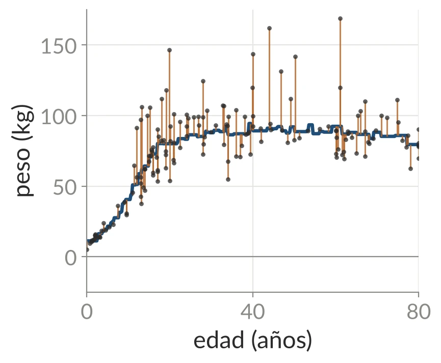

$s_i=|Y_i-\fh(X_i)|,\ \ n=1681$

→

2. Cuantil de los scores

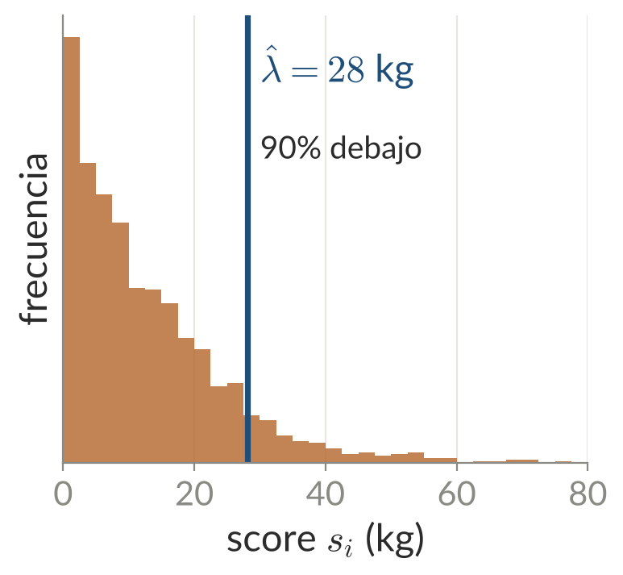

$\qh=28.0$ kg

→

3. Intervalos en test

$\Ch(x)=\big[\fh(x)-\qh,\ \fh(x)+\qh\big]$

## Split conformal

Teorema [Vovk et al, 2005; Lei et al, 2018]

Si $(X_1,Y_1),\dots,(X_{n+1},Y_{n+1})$ son **intercambiables**, entonces
$$\P\big(Y_{n+1}\in\Ch(X_{n+1})\big)\ \ge\ 1-\alpha$$

La probabilidad es sobre los datos de calibración y el dato de test $(X_{n+1},Y_{n+1})$.

**Intercambiables:** con $Z_i=(X_i,Y_i)$, para toda permutación $\pi$,
$$(Z_1,\dots,Z_{n+1})\ \overset{d}{=}\ (Z_{\pi(1)},\dots,Z_{\pi(n+1)}).$$
Por ejemplo, datos i.i.d.

## Split conformal (proof sketch)

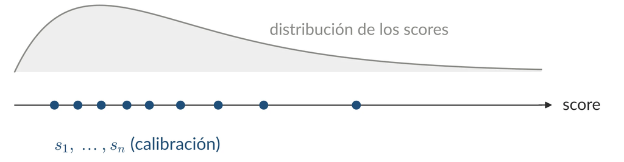

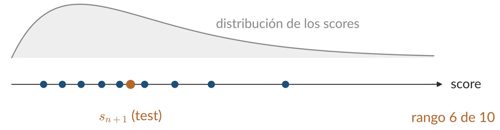

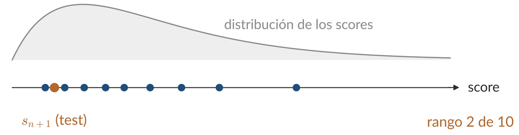

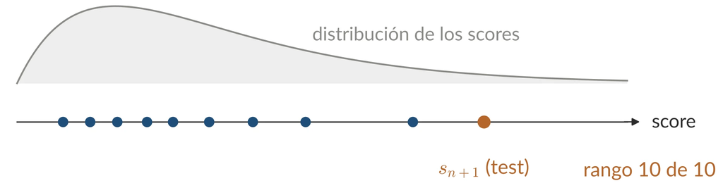

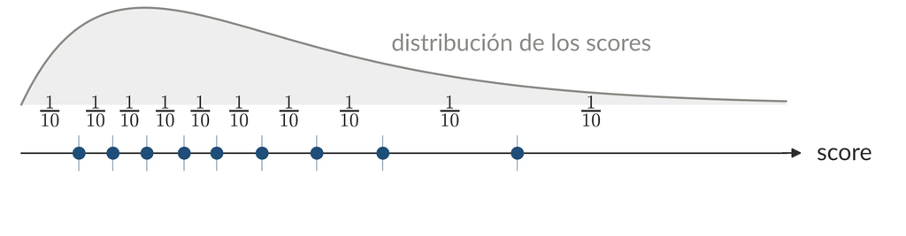

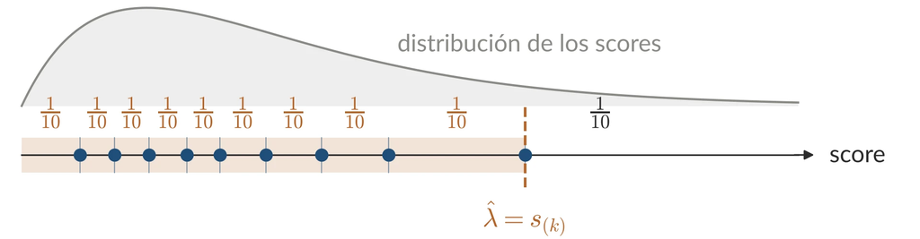

Sea $s_{n+1}=|Y_{n+1}-\fh(X_{n+1})|$, el score de test.

Por intercambiabilidad, el **rango** de $s_{n+1}$ entre $s_1,\dots,s_{n+1}$ es uniforme en $\{1,\dots,n+1\}$.

Con $k=\lceil (n+1)(1-\alpha)\rceil$ y $\qh=s_{(k)}$ ($k$-ésimo en orden creciente):
$$\P\big(Y_{n+1}\in\Ch\big) = \P\big(s_{n+1}\le \qh\big) = \P\big(\text{rango}(s_{n+1}) \le k\big) = \tfrac{k}{n+1} \ge 1-\alpha \quad \square$$

La prueba no usa $\fh$ ni la distribución de $(X,Y)$, i.e. *distribution free*.

## Split conformal

Cobertura en las 1681 personas de test: **89.4%**

$$\P\big(Y_{n+1}\in\Ch(X_{n+1})\big)\ \ge\ 1-\alpha$$

$\{Y_{n+1}\in\Ch(X_{n+1})\}$ es un **evento aleatorio**.

Con una calibración fija:
$$\P\big(Y_{n+1}\in\Ch(X_{n+1})\mid\mathcal D_{\rm cal}\big)\ \sim\ \mathrm{Beta}(n+1-l,\ l)$$
con $l=\lfloor(n+1)\alpha\rfloor$ (scores sin empates)

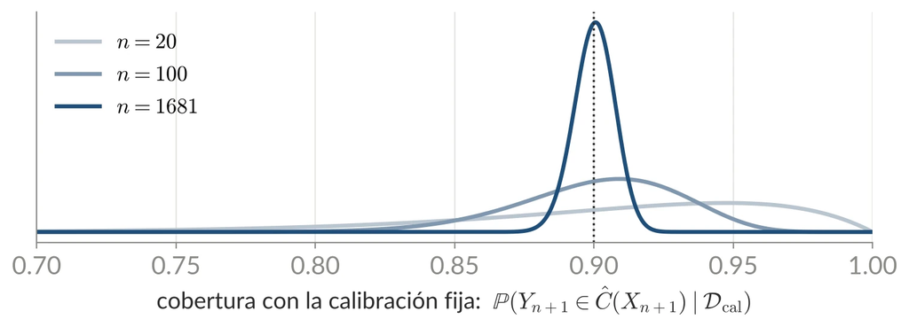

Resumen (hasta acá):

- Split conformal: $\qh$ = cuantil de los errores en calibración.
- Garantía: **intercambiabilidad** + un argumento de **rangos**.
- Cualquier modelo: el modelo determina el **ancho**, no la validez.
- Sin supuestos sobre la distribución y fácil de implementar: uso creciente en ML e IA.

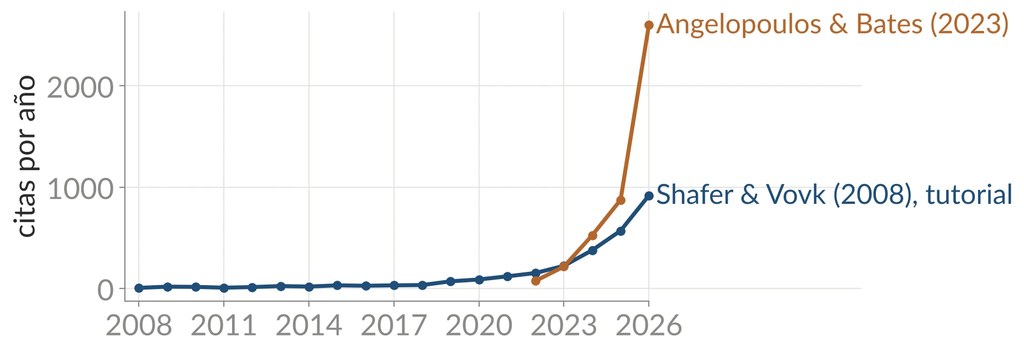

Citas por año en Google Scholar (2026: hasta nov.).

**Elecciones en EE.UU. (2020–2024).** The Washington Post publica en la noche electoral intervalos conformales para los votos aún no contados.  
Cherian, Bronner & Candès, 2024

**Muertes por COVID-19 (pronóstico del CDC).** El pronóstico oficial (sin conformal) publica intervalos del 80% a 4 semanas; en la ola de invierno 2020–21 cubrieron 2 de 10 semanas. Corregidos con conformal en línea: 7 de 10.  
Angelopoulos, Candès & Tibshirani, 2023

Q1: ¿Cómo construir intervalos de incertidumbre precisos?

Q2: ¿Cómo se generaliza y dónde se aplica?

CQR

clasificación

cobertura condicional

control de riesgo

en línea

Q2: ¿Cómo se generaliza y dónde se aplica?

CQR

clasificación

cobertura condicional

control de riesgo

en línea

## Cobertura marginal

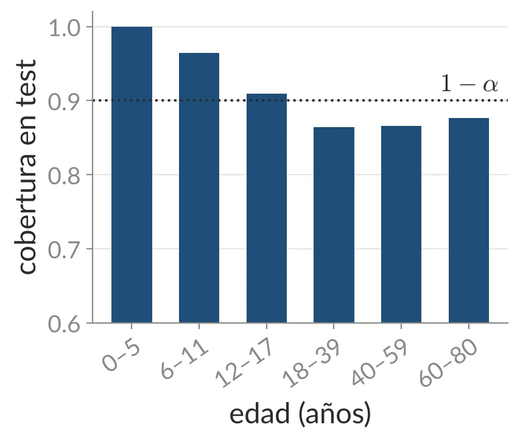

$$\P\big(Y\in\Ch(X)\big)\ge 1-\alpha \qquad\not\Rightarrow\qquad \P\big(Y\in\Ch(X)\mid X=x\big)\ge 1-\alpha$$

## Otros scores

Conformal es muy flexible: cualquier medida heurística de incertidumbre puede usarse como score. Por ejemplo:

- Desviación estándar estimada $\hat\sigma(x)$ (ensamble, MC dropout):
  $$s(x,y)=\frac{|y-\fh(x)|}{\hat\sigma(x)} \qquad\Rightarrow\qquad \Ch(x)=\fh(x)\pm\qh\,\hat\sigma(x)$$
- Regresión cuantílica.

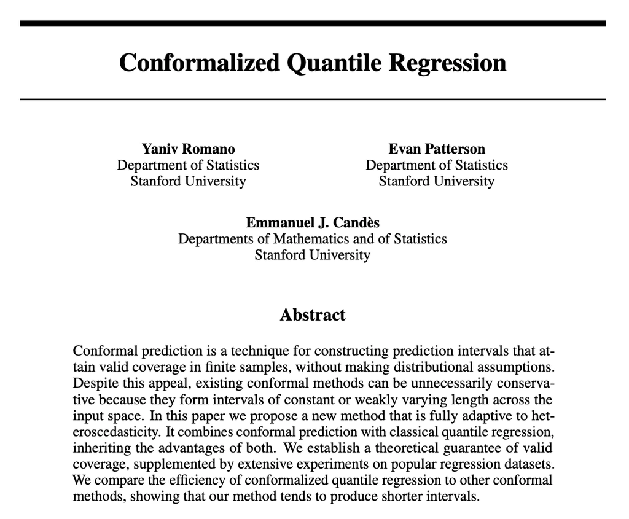

## Regresión cuantílica (CQR)

Estimar los cuantiles 5% y 95% de $Y$ dado $X$: regresión con la pérdida pinball $\ell_\tau$,

$$\hat q_\tau=\arg\min_{q}\ \sum_{i}\ell_\tau\big(Y_i,\,q(X_i)\big)$$

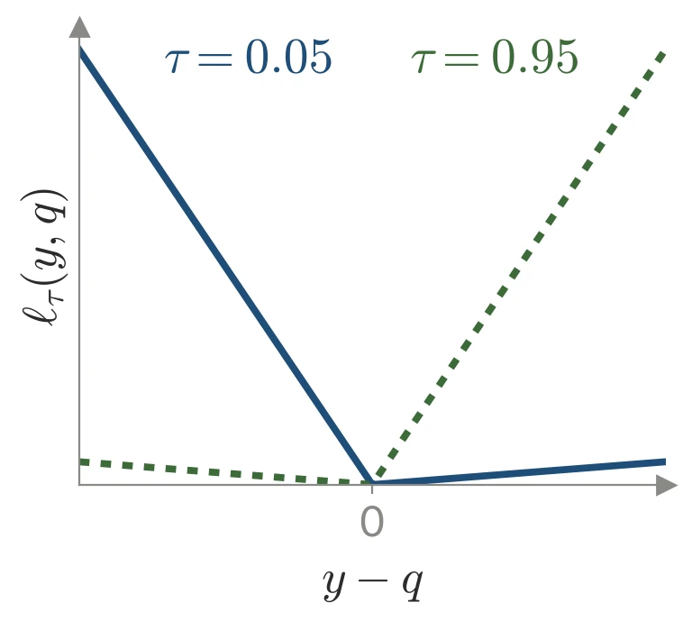

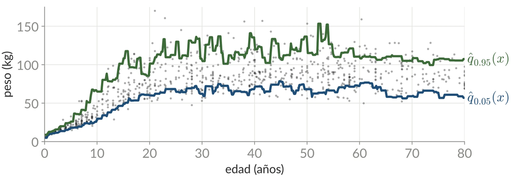

[Romano, Patterson & Candès, 2019]